# STA 141A: Assignment 2

Kyle Guanzon | Student ID: 916279239

**Instructions** You may adapt the code in the course materials or any sources (e.g., the Internet, classmates, friends). In fact, you can craft solutions for almost all questions from the course materials with minor modifications. However, you need to write up your own solutions and acknowledge all sources that you have cited in the Acknowledgement section.

Failing to acknowledge any non-original efforts will be counted as plagiarism. This incidence will be reported to the Student Judicial Affairs.

1. Pick a data set that you find interesting. This data set should contain at least four variables. Briefly explain the data set (background, source, variables, samples, etc.), and why it interests you.

Source: Data SF (Link: https://data.sfgov.org/City-Management-and-Ethics/San-Francisco-City-Survey-Data/nufj-bfbw/about_data)

Description of dataset from page: The San Francisco City Survey asks residents to indicate their usage and satisfaction with city services and infrastructure like libraries, Muni, public safety, and street cleanliness. The City Survey was conducted every year from 1996 to 2004, and biennially from 2005 onward. The City Survey was not conducted in 2019 due to the COVID-19 pandemic, and resumed in 2023. Survey methodology was changed in 2015 from a mail to a phone survey, and expanded to include in-person and online options in 2023. Comparisons to previous years should be interpreted with caution.

I am only focusing on the 2023 dataset.

With a sample size of 2,530, outcomes generally have a ±1.95 percentage point margin of error at a 95% confidence interval, calculated by the survey implementation firms (2023 City Survey Detailed Methodology, Source: https://www.sf.gov/sites/default/files/2023-04/2023%20City%20Survey%20Detailed%20Methodology.pdf).

1,200 residents responded online, 800 by telephone, and 530 via in-person surveys on the street.

InterEthnica and EMC Research administered the survey online, over the telephone, and in-person (2023 City Survey Report, Source: https://www.sf.gov/sites/default/files/2023-04/City%20Survey%202023%20Summary%20Report.pdf).

Survey instrument example: https://www.sf.gov/sites/default/files/2023-04/2023%20City%20Survey%20EN%20101822_FINAL.pdf

2. For Questions 2 to 8, we visit `flights` and `weather` in the `nycflights13` dataset.

```r
# Code obtained from Piazza (Dataset Access HW2)

#Loading package nycflights13
library(nycflights13)
```

1. How many observations and variables are there in the `flights` dataset?

```r
# Code obtained from ChatGPT

# Get the number of observations (rows)
num_observations <- nrow(flights)

# Get the number of variables (columns)
num_variables <- ncol(flights)

# Print the results
cat("Number of observations:", num_observations, "\n")
```

```
## Number of observations: 336776
```

```r
cat("Number of variables:", num_variables, "\n")
```

```
## Number of variables: 19
```

2. Find out the meanings of `talinum`, `flight`, `carrier`, `dep_delay` and `arr_delay` in the `flights` dataset.

```r
?flights
```

From R Documentation, we obtain the meanings of the following variables in the flights dataset: talinum - Plane tail number. See planes for additional metadata. flight - Flight number. carrier - Two letter carrier abbreviation. See airlines to get name. dep_delay - Departure delays, in minutes. Negative times represent early departures. arr_delay - Arrival delays, in minutes. Negative times represent early arrivals.

3. Find out the meanings of `visib`,`time_hour`, and `temp` in the `weather` data set.

```r
?weather
```

From R Documentation, we obtain the meanings of the following variables in the weather dataset: visib - Visibility in miles. time_hour - Date and hour of the recording as a POSIXct date. temp - Temperature in F.

3. Extract the entries for *Alaska Airlines* from the `flights` dataset using `filter()` and `%>%`. Name the selected subset as `alaska_flights`. Furthermore, extract the weather data for EWR airport in January using `filter` and `%>%`, and name it as `early_january_weather` from `weather`.

```r
#Code obtained from ChatGPT

# Extract Alaska Airlines flights
alaska_flights <- flights %>%
  filter(carrier == "AS")

# Extract weather data for EWR airport in January
early_january_weather <- weather %>%
  filter(origin == "EWR" & month == 1)
```

4. Create a scatterplot of `dep_delay` and `arr_delay` in the `alaska_flights` data without using transparency. What do you find about the relationship between these two variable? What are some practical reasons for this relationship?

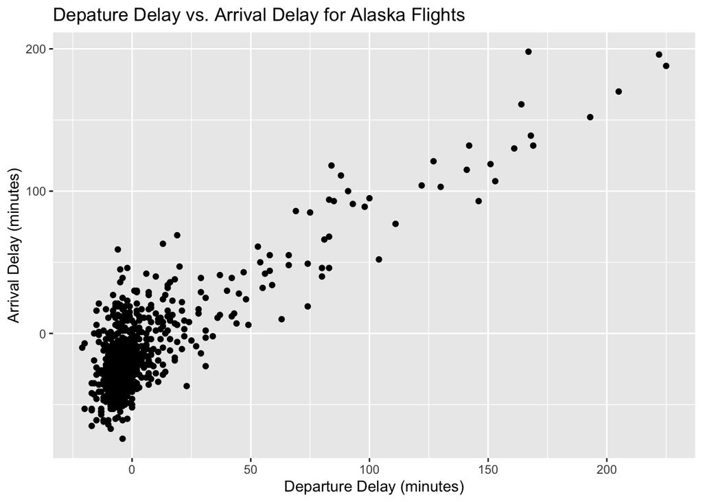

```r
#Code obtained from ChatGPT

# Create scatterplot without transparency
ggplot(alaska_flights, aes(x = dep_delay, y = arr_delay)) +
  geom_point(alpha = 1) +  # Set alpha to 1 for no transparency
  labs(title = "Depature Delay vs. Arrival Delay for Alaska Flights",
       x = "Departure Delay (minutes)",
       y = "Arrival Delay (minutes)")
```

From the scatterplot, we can see a positive relationship between Arrival Delay and Departure Delay. Thus, we can make the assumption that the longer the Departure Delay, the longer the Arrival Delay.

5. Re-draw the plot in Part 4 with transparency set to be 0.2. Compare the two plot and explain your findings, if any.

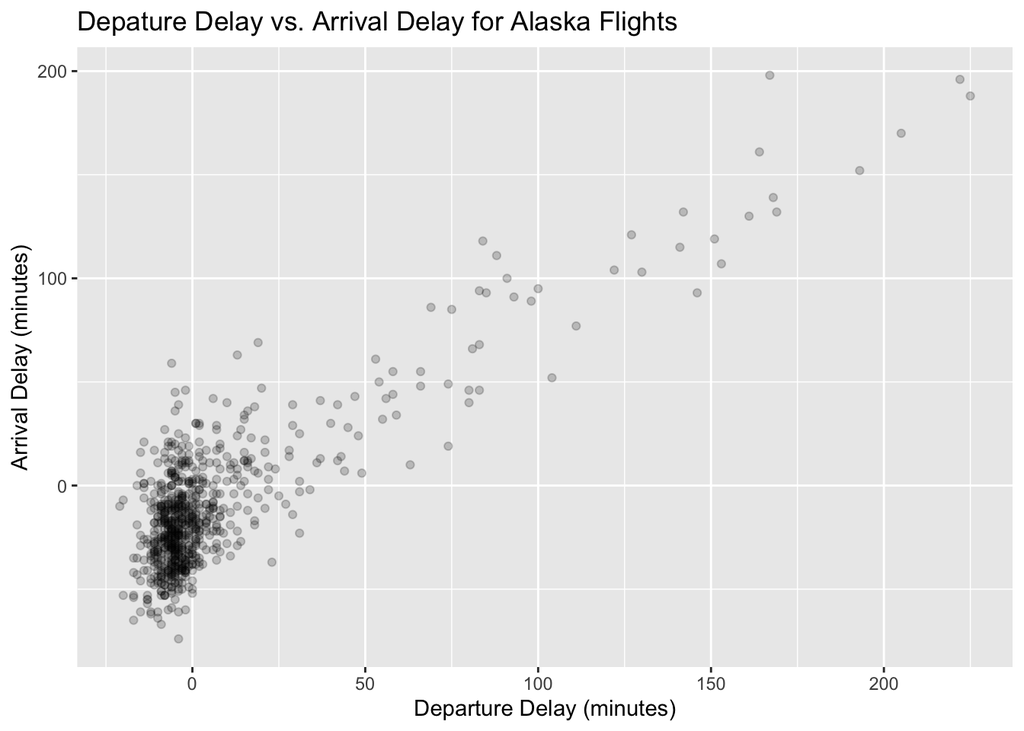

```r
#Code obtained from ChatGPT

# Create scatterplot with transparency set to 0.2
ggplot(alaska_flights, aes(x = dep_delay, y = arr_delay)) +
  geom_point(alpha = 0.2) +  # Set alpha to 0.2 for transparency
  labs(title = "Depature Delay vs. Arrival Delay for Alaska Flights",
       x = "Departure Delay (minutes)",
       y = "Arrival Delay (minutes)")
```

6. For the `early_january_weather` data, create a linegraph with `time_hour` on the `x`-axis and `temp` on the `y`-axis. What do you find from the plot?

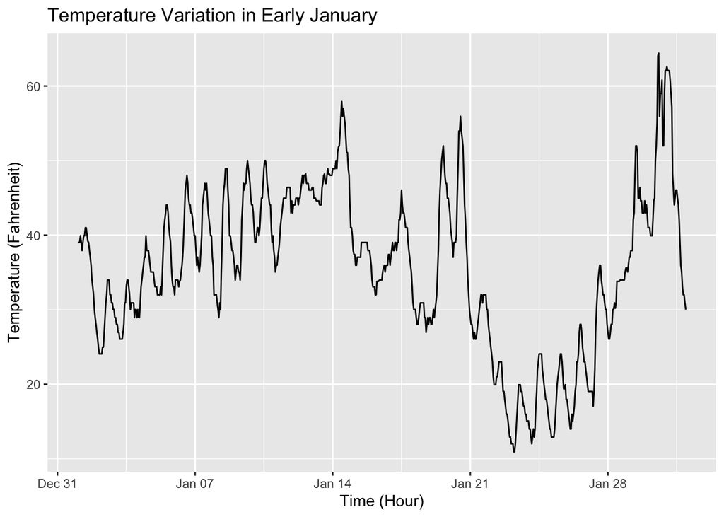

```r
# Code obtained from ChatGPT

# Line graph for temperature over time
ggplot(early_january_weather, aes(x = time_hour, y = temp)) +
  geom_line() +
  labs(title = "Temperature Variation in Early January",
       x = "Time (Hour)",
       y = "Temperature (Fahrenheit)")
```

7. Generate data from the following model.
   $$y_i = x_i\beta_1 + z_i\beta_2+x_i z_i \beta_3+
   \epsilon_i, i = 1,\ldots, 100$$
   where $\beta_1=1$, $\beta_2=2$, $\beta_3 =1$, and $\epsilon_i \sim \mathcal{N}(0,1)$. For $x_i$ and $z_i$, generate them as
   $$x_i \sim\ {\rm uniform} \ (-2,2) \ {\rm
   and}\ z_i =\tilde{\epsilon}_i,$$
   where $\tilde{\epsilon}_i\sim \mathcal{N}(0,0.5)$. Fit a linear regression with $y$ as the outcome and $x$ as the covariate (i.e., without $z$) using `lm()`. Report the estimated coefficients.

```r
# Set seed for reproducibility
set.seed(123)

# Define sample size
n <- 100

# Generate independent variables
x <- runif(n, min = -2, max = 2)
z <- rnorm(n, mean = 0, sd = sqrt(0.5))

# Define coefficients
beta1 <- 1
beta2 <- 2
beta3 <- 1

# Generate error term
epsilon <- rnorm(n)

# Generate dependent variable
y <- x * beta1 + z * beta2 + x * z * beta3 + epsilon

# Create a data frame
data <- data.frame(y, x, z)

# Check the first few rows of the data
head(data)
```

```
##             y          x           z
## 1  0.14409620 -0.8496899  0.17912324
## 2  1.85861312  1.1532205 -0.02018560
## 3 -0.08148062 -0.3640923 -0.03031399
## 4  3.94184616  1.5320696  0.96774796
## 5  1.04185596  1.7618691 -0.15964419
## 6 -1.90276719 -1.8177740  1.07230665
```

```r
# Fit linear regression model
model <- lm(y ~ x, data = data)

# Summary of the model
summary(model)
```

```
##
## Call:
## lm(formula = y ~ x, data = data)
##
## Residuals:
##     Min      1Q  Median      3Q     Max
## -4.3353 -0.9794 -0.0240  0.9729  6.0863
##
## Coefficients:
##             Estimate Std. Error t value Pr(>|t|)
## (Intercept)  -0.0814     0.1802  -0.452    0.652
## x             0.9443     0.1588   5.945 4.26e-08 ***
## ---
## Signif. codes:  0 '***' 0.001 '**' 0.01 '*' 0.05 '.' 0.1 ' ' 1
##
## Residual standard error: 1.802 on 98 degrees of freedom
## Multiple R-squared:  0.265,  Adjusted R-squared:  0.2575
## F-statistic: 35.34 on 1 and 98 DF,  p-value: 4.261e-08
```

```r
coef(model)
```

```
## (Intercept)           x
## -0.08139806  0.94428994
```

8. Wrap the code in Part 7 into a function, and run a simulation of 5000 instances to obtain the estimated coefficients. Draw a histogram of the estimated coefficients $\hat{\beta}_1$s of $x$ from your simulation, add a vertical line (solid, black) to represent the simulation mean, and add another vertical line (dashed, red) to represent the true value (i.e., 1). Report your findings (hint: you may want to review unbiasedness).

```r
# Function to simulate data and fit linear regression model
simulate_and_fit <- function(n) {
  # Generate independent variables
  x <- runif(n, min = -2, max = 2)
  z <- rnorm(n, mean = 0, sd = sqrt(0.5))

  # Define coefficients
  beta1 <- 1
  beta2 <- 2
  beta3 <- 1

  # Generate error term
  epsilon <- rnorm(n)

  # Generate dependent variable
  y <- x * beta1 + z * beta2 + x * z * beta3 + epsilon

  # Create a data frame
  data <- data.frame(y, x, z)

  # Fit linear regression model
  model <- lm(y ~ x, data = data)

  # Return estimated coefficients
  return(coef(model))
}

# Number of simulations
num_simulations <- 5000

# Run simulations
results <- replicate(num_simulations, simulate_and_fit(100))

# Print mean and standard deviation of estimated coefficients
cat("Mean of estimated coefficients:\n")
```

```
## Mean of estimated coefficients:
```

```r
print(apply(results, 1, mean))
```

```
##  (Intercept)            x
## -0.004672214  0.997694278
```

```r
cat("\nStandard deviation of estimated coefficients:\n")
```

```
##
## Standard deviation of estimated coefficients:
```

```r
print(apply(results, 1, sd))
```

```
## (Intercept)           x
##   0.1897851   0.1788364
```

[figure not shown]

```r
# Draw histogram of estimated coefficients
hist(results[1, ], breaks = 30, col = "lightblue", xlab = expression(hat(beta[1])), main = "Histogram of Estimated Coefficients")

# Add vertical line for simulation mean
abline(v = mean(results[1, ]), col = "black", lwd = 2)

# Add vertical line for true value
abline(v = 1, col = "red", lwd = 2, lty = 2)
```

***

9. Report the simulation mean from Part 8. Then run another simulation under the same setting to verify that your simulation is reproducible. Specifically, the new simulation mean should be identical to the mean from Part 8.

```r
# Calculate simulation mean of estimated coefficients
simulation_mean <- mean(results[1, ])

# Print simulation mean
cat("Simulation mean of estimated coefficient (beta1_hat):", simulation_mean, "\n")
```

[output not shown]

```r
# Run another simulation with the same setting
results_new <- replicate(num_simulations, simulate_and_fit(100))

# Calculate simulation mean of estimated coefficients from the new simulation
simulation_mean_new <- mean(results_new[1, ])

# Print simulation mean from the new simulation
cat("Simulation mean of estimated coefficient (beta1_hat) from the new simulation:", simulation_mean_new, "\n")
```

```
## Simulation mean of estimated coefficient (beta1_hat) from the new simulation: 0.001015286
```

```r
# Check if the simulation mean from the new simulation matches the previous one
if(simulation_mean == simulation_mean_new) {
  cat("Simulation is reproducible. The simulation mean is identical to the previous one.\n")
} else {
  cat("Simulation is not reproducible. The simulation mean differs from the previous one.\n")
}
```

```
## Simulation is not reproducible. The simulation mean differs from the previous one.
```

10. Generate data from a similar model.
    $$y_i = x_i\beta_1 + z_i\beta_2+\epsilon_i, i
    = 1,\ldots, 100$$
    where $\beta_1=1$, $\beta_2=2$, and $\epsilon_i \sim \mathcal{N}(0,1)$. For $x_i$ and $z_i$, generate them as
    $$x_i \sim\ {\rm uniform} \ (-2,2) \ {\rm
    and}\ z_i = \gamma_1 x_i+\gamma_0+\tilde{\epsilon}_i,$$
    where $\gamma_1=1$, $\gamma_0=1$and $\tilde{\epsilon}_i\sim \mathcal{N}(0,0.5)$. Suppose we fit a regression model with $y$ as the outcome and $x$ as the covariate (i.e., without $z$). Examine whether, in this model, the estimator for the coefficient of $x$ is unbiased using simulation.

```r
# Set seed for reproducibility
set.seed(123)

# Define sample size
n <- 100

# Number of simulations
num_simulations <- 1000

# Define true coefficient for x
true_coeff_x <- 1

# Initialize vector to store estimated coefficients
estimated_coefficients <- numeric(num_simulations)

# Simulation loop
for (i in 1:num_simulations) {
  # Generate independent variable x
  x <- runif(n, min = -2, max = 2)

  # Define coefficients for z
  gamma1 <- 1
  gamma0 <- 1

  # Generate error term for z
  epsilon_z <- rnorm(n, mean = 0, sd = sqrt(0.5))

  # Generate dependent variable z
  z <- gamma1 * x + gamma0 + epsilon_z

  # Generate error term for y
  epsilon_y <- rnorm(n)

  # Generate dependent variable y
  y <- x * true_coeff_x + z * 0 + epsilon_y

  # Fit linear regression model
  model <- lm(y ~ x)

  # Store estimated coefficient for x
  estimated_coefficients[i] <- coef(model)[2]  # Index 2 corresponds to the coefficient for x
}

# Calculate bias of the estimated coefficient for x
bias <- mean(estimated_coefficients - true_coeff_x)

# Print bias
cat("Bias of the estimated coefficient for x:", bias, "\n")
```

```
## Bias of the estimated coefficient for x: -0.0001542532
```

## Acknowledgement

Failing to acknowledge any non-original efforts will be counted as plagiarism. This incidence will be reported to the Student Judicial Affairs.

If you use generative AI to solve any questions, please provide your instructions, conversations, and prompts here.

ChatGPT Code Chunk:

[output not shown]

[output not shown]

[output not shown]

[output not shown]